# Exploratary_Data_Analysis

Varghees Joseph

10/22/2019

## **Part I**

## **About the Data**

### The Behavioral Risk Factor Surveillance System (BRFSS) is a collaborative project between all of the states in the United States (US) and participating US territories and the Centers for Disease Control and Prevention (CDC). The BRFSS is designed to collect uniform, state-specific data on preventive health practices and risk behaviors that are linked to chronic diseases, injuries, and preventable infectious diseases that affect the adult population. tobacco use, HIV/AIDS knowledge and prevention, exercise, immunization, health status, healthy days — health-related quality of life, health care access, inadequate sleep, hypertension awareness, cholesterol awareness, chronic health conditions, alcohol consumption, fruits and vegetables consumption, arthritis burden, and seatbelt use are some of the factors assessed by the BRFSS in 2013.

## **Methodolgy of the Data**

### The BRFSS was initiated in 1984, with 15 states collecting surveillance data on risk behaviors through monthly telephone interviews. Over time, the number of states participating in the survey increased; by 2001, 50 states, the District of Columbia, Puerto Rico, Guam, and the US Virgin Islands were participating in the BRFSS. Today, all 50 states, the District of Columbia, Puerto Rico, and Guam collect data annually and American Samoa, Federated States of Micronesia, and Palau collect survey data over a limited point- in-time (usually one to three months). In this document, the term “state” is used to refer to all areas participating in BRFSS, including the District of Columbia, Guam, and the Commonwealth of Puerto Rico. Disproportionate stratified sampling (DSS) has been used for the landline sample and the cellular telephone respondents are randomly selected with each having equal probability of selection. The dataset we are working on contains 330 variables for a total of 491, 775 samples in 2013. All missing values are coded NA in the R Workspace.

## **Generalizability**

### The BRFSS is a survey of 491,775 U.S. adults i.e. 18 years or older. The survey follows a *large stratified random sample*. Due to the nature of the data it is susceptible to some biases associated with non-response, incomplete interviews and missing values. But the sample data allows us to generalize to the population of interest.

## **Causality**

### Only non-causal and correlation statements can be made using the results from the data as BRFSS is simply an observational study. While the data is collected using large stratified random sample theres is **no random assignment** and therefore, using BRFSS data we can establish only correlation/association between variables.

# Load packages

```r
library(ggplot2)
library(dplyr)
load("C:/Users/IIMT/Desktop/vj/Coursera/Stats with R/_384b2d9eda4b29131fb681b243a7767d_brfss2013/Intro_Data_Prob_Project.Rdata")
```

# **Part II**

## Research quesion III

### Is there a correlation between being number of hours worked per week and poor health?

## Research question IV

### Is there a correlation between being a veteran and poor physical or mental health? Are those results affected by the binge drinking habits of the population?

# **Part III**

## Exploratory Data Analysis

### **Research quesion I**

### **Is there any association between income and health care coverage?**

### We can use a Barplot find if there is any association between income and health care coverage.

### Plotting the data

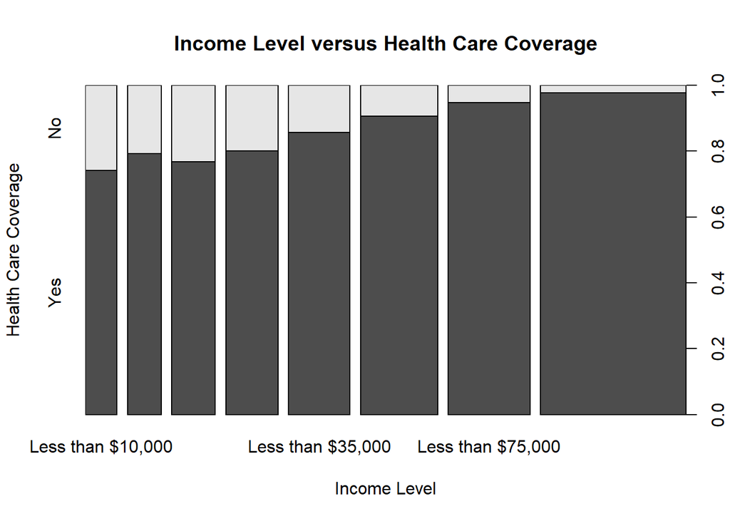

```r
plot(brfss2013$income2, brfss2013$hlthpln1, xlab = 'Income Level', ylab = 'Health Care Coverage', main =
       'Income Level versus Health Care Coverage')
```

### We have more than two variable in this case. So let us first summarize each variable in order to understand the nature and distribution of the data.

```r
brfss2013 %>%
  group_by(educa) %>%
  summarise(count=n())
```

```
## # A tibble: 7 x 2
##   educa                                                         count
##   <fct>                                                         <int>
## 1 Never attended school or only kindergarten                      677
## 2 Grades 1 through 8 (Elementary)                               13395
## 3 Grades 9 though 11 (Some high school)                         28141
## 4 Grade 12 or GED (High school graduate)                       142971
## 5 College 1 year to 3 years (Some college or technical school) 134197
## 6 College 4 years or more (College graduate)                   170120
## 7 <NA>                                                           2274
```

```r
brfss2013 %>%
  group_by(genhlth) %>%
  summarise(count=n())
```

```
## # A tibble: 6 x 2
##   genhlth    count
##   <fct>      <int>
## 1 Excellent  85482
## 2 Very good 159076
## 3 Good      150555
## 4 Fair       66726
## 5 Poor       27951
## 6 <NA>        1985
```

```r
brfss2013 %>%
  group_by(X_rfsmok3) %>%
  summarise(count=n())
```

```
## Warning: Factor `X_rfsmok3` contains implicit NA, consider using
## `forcats::fct_explicit_na`
```

```
## # A tibble: 3 x 2
##   X_rfsmok3  count
##   <fct>      <int>
## 1 No        399786
## 2 Yes        76654
## 3 <NA>       15335
```

### We get a Warning message stating the data contains implicit NA. So we create a new dataset by cleaning the NAs from the variables and summarize them again.

### Cleaning the data

```r
brfss2013_cleaned_1 <- brfss2013 %>%
  filter(!(is.na(genhlth)), !(is.na(educa)), !(is.na(X_rfsmok3)))

brfss2013_cleaned_1 %>%
  group_by(educa) %>%
  summarise(count=n())
```

```
## # A tibble: 6 x 2
##   educa                                                         count
##   <fct>                                                         <int>
## 1 Never attended school or only kindergarten                      616
## 2 Grades 1 through 8 (Elementary)                               12647
## 3 Grades 9 though 11 (Some high school)                         26889
## 4 Grade 12 or GED (High school graduate)                       137559
## 5 College 1 year to 3 years (Some college or technical school) 130158
## 6 College 4 years or more (College graduate)                   165436
```

```r
brfss2013_cleaned_1 %>%
  group_by(genhlth) %>%
  summarise(count=n())
```

```
## # A tibble: 5 x 2
##   genhlth    count
##   <fct>      <int>
## 1 Excellent  82438
## 2 Very good 154370
## 3 Good      145207
## 4 Fair       64355
## 5 Poor       26935
```

```r
brfss2013_cleaned_1 %>%
  group_by(X_rfsmok3) %>%
  summarise(count=n())
```

```
## # A tibble: 2 x 2
##   X_rfsmok3  count
##   <fct>      <int>
## 1 No        397105
## 2 Yes        76200
```

### Labelling

### Here we are simply renaming the variables so that it will be easier for our understanding.

```r
levels(brfss2013_cleaned_1$educa) <-
  c("kindergarten", "Elementary", "Some high school", "High school graduate", "Some college", "College graduate")
```

### Plotting the data

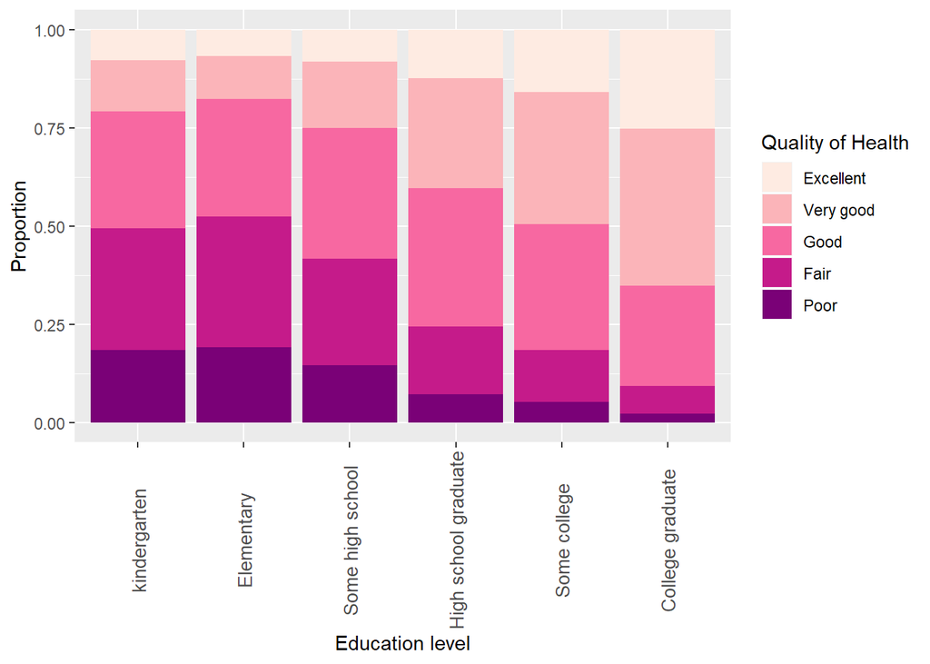

```r
edu_hlt_bar <-
  ggplot(brfss2013_cleaned_1) + aes(x= educa,fill=genhlth) + geom_bar(position = "fill")

edu_hlt_bar <-
  edu_hlt_bar + xlab("Education level") + ylab("Proportion") + scale_fill_brewer(name="Quality of Health", palette = "RdPu") + theme(axis.text.x = element_text(angle =90, size = 10, vjust = 0.5))

edu_hlt_bar
```

### We can see that as level of education completed increases, the proportion of people reporting a better general health also increases.

### Let’s add the variable for smokers to the graph to see if there is any difference between the smokers and nonsmokers.

### Plotting the data

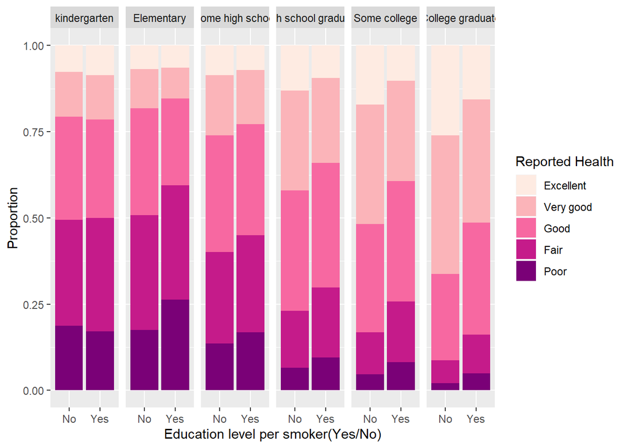

```r
edu_hlt_bar_smoke <-
  ggplot(brfss2013_cleaned_1) + aes(x= X_rfsmok3,fill=genhlth) + geom_bar(position = "fill") + facet_grid(.~educa)

edu_hlt_bar_smoke <-
  edu_hlt_bar_smoke + xlab("Education level per smoker(Yes/No)") + ylab("Proportion") + scale_fill_brewer(name="Reported Health", palette = "RdPu")

edu_hlt_bar_smoke
```

### **Finding**

### We can see from the bar chart that not only there is a difference in the health reported by respondent according to whether they are smokers or not but also the difference of reported health amongst respondent with lowest education, does not vary much according to whether they are smokers of not. Therefore, smoking habit seems to make a difference on reported quality of health especially on those who have a higher education.

### Research quesion III

### **Is there a correlation between being number of hours worked per week and poor health?**

### Cleaning the data

```r
brfss2013_cleaned_2 <- brfss2013 %>%
  filter(!(is.na(scntwrk1)), !(is.na(genhlth))) %>%
  group_by(scntwrk1) %>%
  summarize(poorhlthpct = sum(genhlth == "Poor") * 100 / n()) %>%
  arrange(desc(poorhlthpct)) %>%
  mutate(poorhlthpct = poorhlthpct)
```

```r
View(brfss2013_cleaned_2)
print(brfss2013_cleaned_2)
```

```
## # A tibble: 93 x 2
##    scntwrk1 poorhlthpct
##       <int>       <dbl>
##  1       82       50
##  2       95       14.3
##  3        3        9.09
##  4       98        8.62
##  5       11        6.25
##  6       28        6.20
##  7       14        5.88
##  8       19        5
##  9       21        5
## 10        5        4.85
## # ... with 83 more rows
```

```r
brfss2013_cleaned_2 %>%
  print(n=20)
```

```
## # A tibble: 93 x 2
##    scntwrk1 poorhlthpct
##       <int>       <dbl>
##  1       82       50
##  2       95       14.3
##  3        3        9.09
##  4       98        8.62
##  5       11        6.25
##  6       28        6.20
##  7       14        5.88
##  8       19        5
##  9       21        5
## 10        5        4.85
## 11        2        4.76
## 12       26        4.65
## 13       22        4.44
## 14       16        4.35
## 15       12        3.59
## 16       85        3.23
## 17       37        2.86
## 18       18        2.78
## 19        6        2.70
## 20        4        2.67
## # ... with 73 more rows
```

### Plotting the data

```r
brfss2013_cleaned_2 <-
  ggplot(data = brfss2013_cleaned_2, aes(x = scntwrk1, y = poorhlthpct)) + geom_point() + geom_line()
```

```r
brfss2013_cleaned_2 <-
  brfss2013_cleaned_2 + xlab("Hours Worked Per Week") + ylab("Percentage With Poor Health")
```

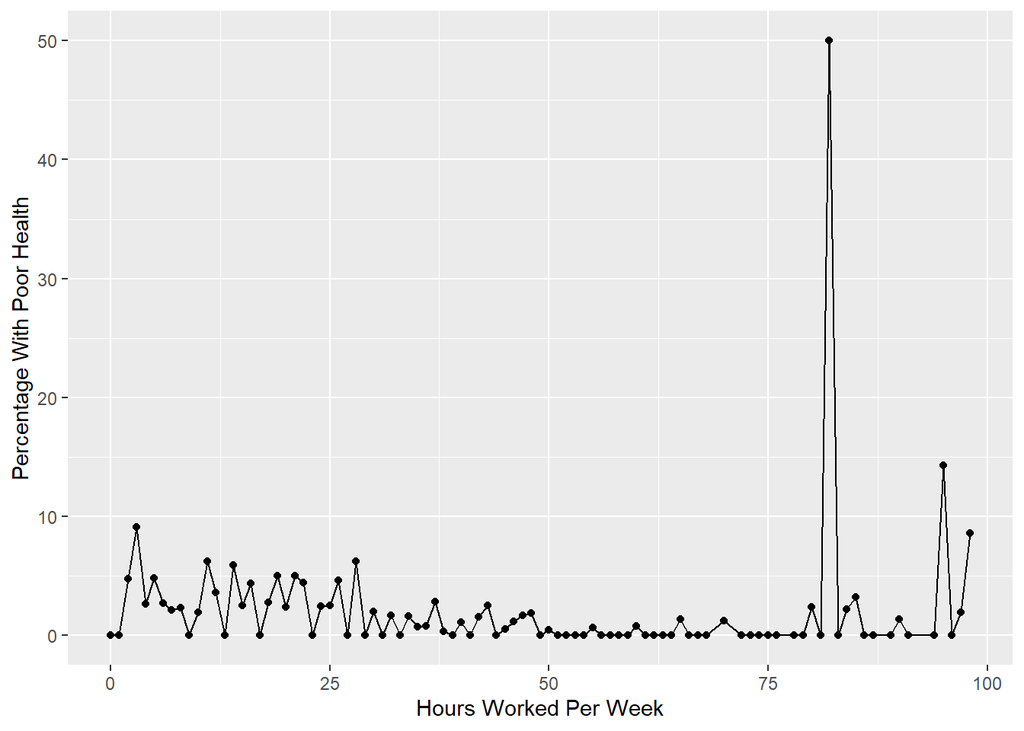

```r
brfss2013_cleaned_2
```

### **Finding**

### The majority of the plot follows that of a roughly right skewed distribution, with a significant outlier around 80 hours worked. The distribution follows a zigzag trend stating that there is a loose correlation between the number of hours worked per week and reporting poor health based on the distribution.

## Research question IV

### **Is there a correlation between being a veteran and poor physical or mental health? Are those results affected by the binge drinking habits of the population?**

### Cleaning the data

```r
brfss2013_cleaned_3 <- brfss2013 %>%
  filter(!(is.na(veteran3)), !(is.na(poorhlth)), !(is.na(drnk3ge5)))
brfss2013_cleaned_3 <- brfss2013_cleaned_3 %>%
  mutate(poorhlth = ifelse(poorhlth > 7, "8+", poorhlth))
brfss2013_cleaned_3$poorhlth <- factor(brfss2013_cleaned_3$poorhlth)
brfss2013_cleaned_3 <- brfss2013_cleaned_3 %>%
  mutate(drnk3ge5 = ifelse(drnk3ge5 > 7, "8+", drnk3ge5))
```

### Summary Statistics

```r
brfss2013_cleaned_3 %>%
  group_by(drnk3ge5, veteran3) %>% summarize(count=n())
```

```
## # A tibble: 18 x 3
## # Groups:   drnk3ge5 [9]
##    drnk3ge5 veteran3 count
##    <chr>    <fct>    <int>
##  1 0        Yes      10172
##  2 0        No       71720
##  3 1        Yes       1020
##  4 1        No       10332
##  5 2        Yes        661
##  6 2        No        5870
##  7 3        Yes        296
##  8 3        No        2732
##  9 4        Yes        291
## 10 4        No        2553
## 11 5        Yes        226
## 12 5        No        1885
## 13 6        Yes        102
## 14 6        No         731
## 15 7        Yes         48
## 16 7        No         458
## 17 8+       Yes        685
## 18 8+       No        3874
```

```r
brfss2013_cleaned_3 %>%
  group_by(poorhlth, veteran3) %>% summarize(count=n())
```

```
## # A tibble: 18 x 3
## # Groups:   poorhlth [9]
##    poorhlth veteran3 count
##    <fct>    <fct>    <int>
##  1 0        Yes       7853
##  2 0        No       61212
##  3 1        Yes        611
##  4 1        No        6639
##  5 2        Yes        758
##  6 2        No        6693
##  7 3        Yes        476
##  8 3        No        3756
##  9 4        Yes        280
## 10 4        No        1986
## 11 5        Yes        511
## 12 5        No        3680
## 13 6        Yes         93
## 14 6        No         598
## 15 7        Yes        227
## 16 7        No        1922
## 17 8+       Yes       2692
## 18 8+       No       13669
```

### Plotting the data

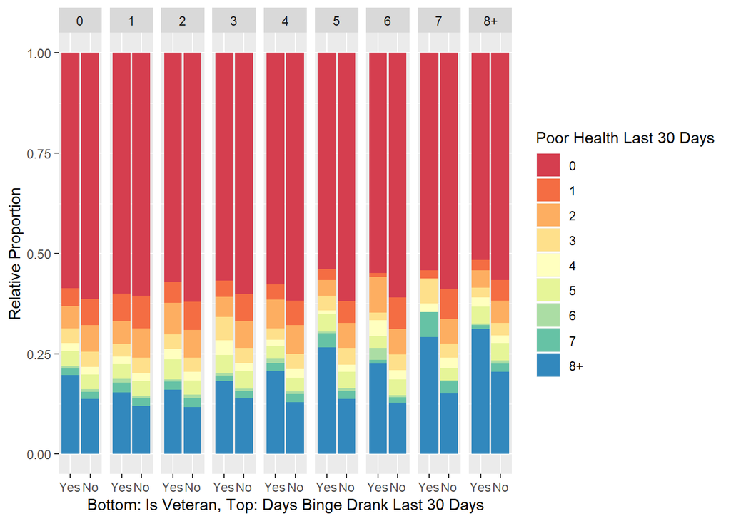

```r
brfss2013_cleaned_3 <-
  ggplot(brfss2013_cleaned_3) + aes(x = veteran3, fill = poorhlth) + geom_bar(position = "fill") + facet_grid(.~drnk3ge5)
brfss2013_cleaned_3 <- brfss2013_cleaned_3 + scale_fill_brewer(name="Poor Health Last 30 Days", palette = "Spectral") + xlab("Bottom: Is Veteran, Top: Days Binge Drank Last 30 Days") + ylab("Relative Proportion")
brfss2013_cleaned_3
```

# *Thank you.*